| National Park Service U.S. Department of the Interior Natural Resource Stewardship and Science |  |
| --- | --- |

# Summer Temperature Regimes in Northeast Coastal and Barrier Network Eelgrass Meadows

July 07, 2026

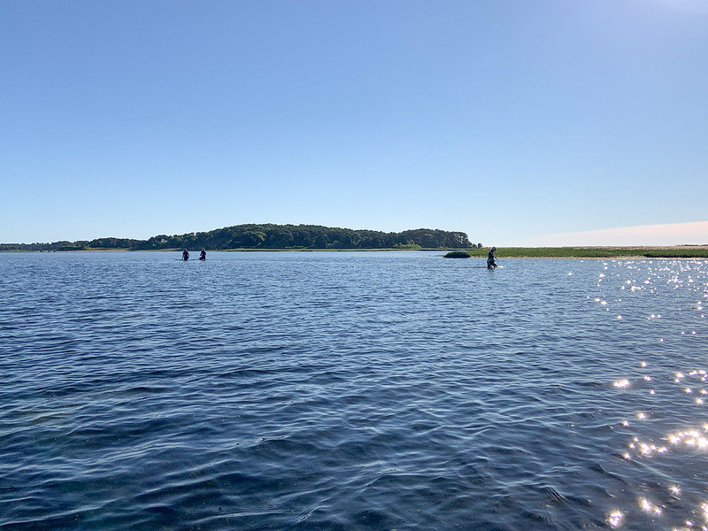

Cover: Field crew conducting seagrass monitoring in Pleasant Bay at Cape Cod National Seashore.

# Background

## Eelgrass Importance and Vulnerability

Eelgrass (*Zostera marina*) is a foundational marine plant that supports healthy coastal ecosystems. It improves water quality, stabilizes sediments, provides habitat for fish and invertebrates (Orth et al. 2006, Hemminga & Duarte 2000, Orth et al. 2020), and also functions as both a global and local carbon sink (Sogin et al. 2022, Fourqurean et al. 2012, Novak et al. 2020). Because eelgrass responds quickly to environmental change, it is often considered a “canary in the coal mine” for coastal health (Orth et al. 2006). Its ecological significance is one reason the Northeast Coastal and Barrier Network (NCBN) monitors seagrass condition over time, especially as concerns grow about the effects of warming waters.

Globally, sea surface temperatures (SST) have increased significantly over the past century and are projected to continue rising throughout the 21st century (IPCC, 2023). In recent decades, eelgrass in park units along the Northeast U.S. coast has experienced water temperatures that approach or exceed physiological limits (Nagel et. al 2025a,b,c). When water becomes too warm, eelgrass respiration outpaces photosynthesis, creating physiological stress that can lead to mortality; conversely, cooling periods allow these processes to rebalance, enabling plants to rebuild the carbohydrate reserves needed for growth, biomass, and winter survival (Lee et al. 2007, Marín-Guirao et al. 2016, Marsh et al. 1986). Studies show that temperatures above 25 °C increase the likelihood of eelgrass mortality in Nantucket, MA, and sustained exposure above 30 °C has caused complete die offs in areas such as Chesapeake Bay (Novak et al. 2023, Jarvis & Moore 2010). Long-term temperature records from New Hampshire to Maryland show that warmer than average summers are consistently followed by reduced eelgrass presence the following year (Plaisted et al. 2022). When high temperature events persist without cooling relief, eelgrass may lose the opportunity to recover from heat stress, causing stress impacts to accumulate and increasing the risk of widespread decline (Berger et al. 2024).

These patterns of warmer summers, increased physiological stress, and fewer opportunities for recovery reflect broader climate driven trends. Marine heatwaves, periods when water temperatures exceed the 90<sup>th</sup> percentile of a 30 year baseline, have become more frequent and intense (Hobday et al 2016). Such events have already affected corals, kelp forests, and seagrasses worldwide (Smale et al. 2019). Research shows that eelgrass meadows experiencing both high heat and minimal cooling tend to lose shoot density and canopy height, while sites that receive periodic cooling recover more effectively between heat events (Berger et al. 2024).

Cumulative heat stress metrics are widely used to understand ecosystem and species-level impacts. NOAA’s Degree Heating Weeks (DHW) index, for example, tracks how often and for how long temperatures exceed thresholds that lead to coral bleaching and mortality (Skirving et al. 2020). These metrics emphasize that it is the accumulation of heat over time, not isolated temperature spikes, that often drive ecosystem decline. This same concept is applicable to eelgrass.

Characterizing the temperature regimes that influence eelgrass heat stress and recovery requires long-term temperature datasets. To better understand the thermal conditions shaping eelgrass meadow health within Northeast Coastal and Barrier Network parks, we used long-term temperature datasets to:

1. Identify years with extreme heat and limited cooling,
2. Determine when and where these conditions overlapped to create compounded “stress years,” and
3. Compare thermal regimes across eelgrass meadows to understand regional vulnerability.

While temperature is a key factor of eelgrass stress and recovery, it interacts with other environmental factors including water clarity, nutrients, salinity, and dissolved oxygen, that together drive meadow conditions (Lefcheck et al. 2017, Dunic & Cote 2023, Moore et al. 2012). This report focuses on characterizing thermal regimes as a foundational step. Future analyses will explore how temperature interacts with these additional factors to drive patterns in eelgrass condition across NCBN parks.

# Methods

## Temperature Data Collection

Three coastal parks within NCBN, Assateague Island National Seashore (ASIS), Cape Cod National Seashore (CACO), and Fire Island National Seashore (FIIS) implement a standardized seagrass condition monitoring protocol (Kopp & Neckles 2009) designed to track changes in seagrass beds across depth-stratified transects. As a component of this protocol, temperature loggers (HOBO UTBI-001 Tidbit Temp, Onset Computer Corporation) are deployed at each long-term seagrass monitoring site and record water temperature at 15-minute intervals continuously throughout the year.

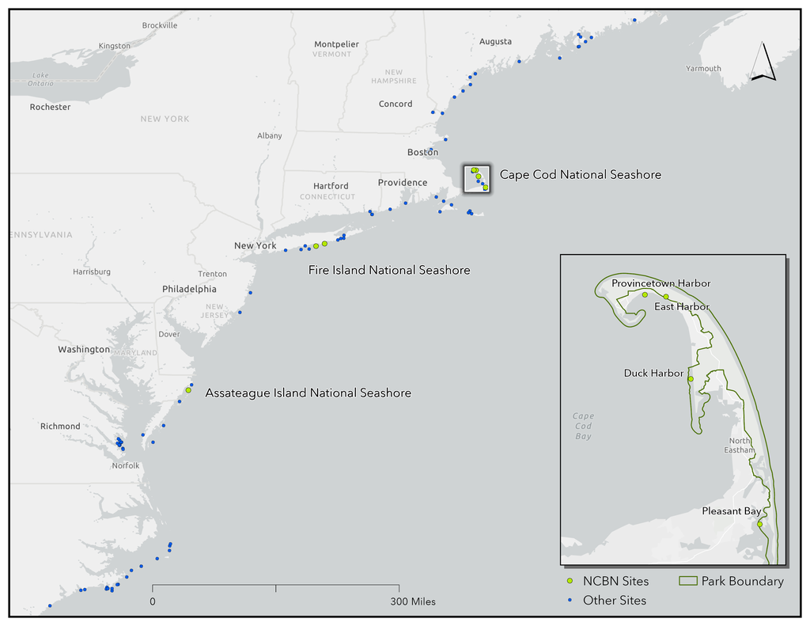

Figure 1. Locations of coastal temperature loggers across the East Coast study area. Green markers indicate long-term NCBN monitoring sites, and blue markers represent shorter-term deployments. The inset map provides a magnified view of sites within CACO, illustrating the spatial distribution of NCBN monitoring site locations along the park’s shoreline. The park boundary is shown in green. *Source:NPS/MCompo.*

## Data Summarization & Analysis

For this analysis, we focused on continuous water temperature data and examined patterns of thermal stress and cooling dynamics to understand the thermal conditions at the CACO Duck Harbor and Pleasant Bay seagrass monitoring sites and to compare these metrics with long-term seagrass monitoring sites at ASIS and FIIS.

Prior to analyses, temperature data were filtered to include the months of May-September to focus on the period when thermal stress is most likely to occur. To ensure that thermal metrics were comparable across years, sampling years with insufficient data coverage were excluded from analysis. Specifically, only years with 80% data coverage and a minimum of 10 days of data in at least three of the five focal months were retained (Table 1). Sampling years not meeting these criteria were excluded to avoid skewed thermal metrics caused by gaps in the temperature record.

At long-term monitoring sites with multiple transects (shallow, mid-depth, deep), temperature observations were initially calculated at the transect level. Preliminary comparisons showed that although transects differ in depth, they exhibited similar annual temperature trajectories. Because our goal was to describe site‑level thermal conditions for regional analyses rather than depth‑specific patterns, transect data were averaged within each site‑year to produce a single annual observation. Transect-level differences are preserved in the underlying dataset and can be examined separately when depth-specific patterns are of interest, but year-level thermal metrics are summarized at the site scale to support cross park comparisons.

Table 1. Retention of years for analyses (CACO). Years retained meet both rules: ≥80% coverage and ≥10 data-days in ≥3 months (May–September). In the Transect column, A indicates shallow depth, B indicates mid-depth, and C indicates deep.

| Site | Year | Transect | Coverage (%) | # Months ≥10 Days | Monthly Days Check | Meets Both Criteria | Retained for Analysis? | Reason Not Retained |
| --- | --- | --- | --- | --- | --- | --- | --- | --- |
| Duck Harbor | 2003 | A | 49.7 | 3 | TRUE | FALSE | No | Coverage < 80 |
| Duck Harbor | 2003 | C | 68.0 | 4 | TRUE | FALSE | No | Coverage < 80 |
| Duck Harbor | 2004 | A | 81.0 | 4 | TRUE | TRUE | Yes |  |
| Duck Harbor | 2004 | C | 81.0 | 4 | TRUE | TRUE | Yes |  |
| Duck Harbor | 2005 | A | 100.0 | 5 | TRUE | TRUE | Yes |  |
| Duck Harbor | 2005 | C | 100.0 | 5 | TRUE | TRUE | Yes |  |
| Duck Harbor | 2006 | A | 100.0 | 5 | TRUE | TRUE | Yes |  |
| Duck Harbor | 2006 | C | 100.0 | 5 | TRUE | TRUE | Yes |  |
| Duck Harbor | 2007 | A | 100.0 | 5 | TRUE | TRUE | Yes |  |
| Duck Harbor | 2007 | C | 100.0 | 5 | TRUE | TRUE | Yes |  |
| Duck Harbor | 2008 | A | 100.0 | 5 | TRUE | TRUE | Yes |  |
| Duck Harbor | 2008 | C | 100.0 | 5 | TRUE | TRUE | Yes |  |
| Duck Harbor | 2009 | A | 100.0 | 5 | TRUE | TRUE | Yes |  |
| Duck Harbor | 2009 | C | 100.0 | 5 | TRUE | TRUE | Yes |  |
| Duck Harbor | 2010 | A | 100.0 | 5 | TRUE | TRUE | Yes |  |
| Duck Harbor | 2010 | C | 100.0 | 5 | TRUE | TRUE | Yes |  |
| Duck Harbor | 2011 | A | 100.0 | 5 | TRUE | TRUE | Yes |  |
| Duck Harbor | 2011 | C | 100.0 | 5 | TRUE | TRUE | Yes |  |
| Duck Harbor | 2012 | A | 100.0 | 5 | TRUE | TRUE | Yes |  |
| Duck Harbor | 2012 | C | 23.5 | 1 | FALSE | FALSE | No | Both |
| Duck Harbor | 2013 | A | 100.0 | 5 | TRUE | TRUE | Yes |  |
| Duck Harbor | 2013 | C | 64.1 | 3 | TRUE | FALSE | No | Coverage < 80 |
| Duck Harbor | 2014 | A | 100.0 | 5 | TRUE | TRUE | Yes |  |
| Duck Harbor | 2014 | C | 100.0 | 5 | TRUE | TRUE | Yes |  |
| Duck Harbor | 2015 | A | 100.0 | 5 | TRUE | TRUE | Yes |  |
| Duck Harbor | 2015 | C | 100.0 | 5 | TRUE | TRUE | Yes |  |
| Duck Harbor | 2016 | A | 100.0 | 5 | TRUE | TRUE | Yes |  |
| Duck Harbor | 2016 | C | 100.0 | 5 | TRUE | TRUE | Yes |  |
| Duck Harbor | 2017 | A | 100.0 | 5 | TRUE | TRUE | Yes |  |
| Duck Harbor | 2017 | C | 100.0 | 5 | TRUE | TRUE | Yes |  |

[output cut: 79 more lines]

### Novel Thermal Metrics for Eelgrass

For eelgrass, prolonged exposure to high temperatures can lead to physiological stress when respiration outpaces photosynthesis. To describe long-term thermal conditions in eelgrass meadows, we calculated two site-level yearly metrics from the continuous water temperature data: **heating degree hours (HDH)** and **cooling degree hours (CDH)** (Berger et al. 2024). Heating Degree Hours were calculated by summing the hourly temperature exceedance above a park-specific temperature threshold across the focal months (May–September), yielding the total HDH for each year. Annual HDH values were then divided by the total number of hours in the observation period to calculate mean HDH per year. Similarly, mean annual CDH was calculated using the same approach for hourly temperatures below the park-specific temperature threshold.

Park-specific temperature thresholds were calculated from the filtered water temperature data described in the previous section. We first calculated the mean monthly temperature for each month between May to September across all years for each transect at each site (i.e., transect-level mean monthly temperatures). Then, we calculated the maximum of the transect-level mean monthly temperatures for each site. We used maximum temperatures because the distribution of seagrasses (and many other vegetation communities - such as mangroves) have been shown to be controlled in part by the frequency and intensity of climate extremes (Germain & Lutz 2020, Osland et al. 2017, Parmesan et al. 2000, Zimmermann et al. 2009), which are also expected to increase due to climate change (Easterling et al. 2000, IPCC 2013, Jentsch & Beierkuhnlein 2008, Meehl & Tebaldi 2004). Finally, we averaged the maximum mean monthly temperature from the site with the lowest value and the site with the highest value within each park to calculate a park-specific temperature threshold value. For park units with only one monitoring site (e.g ASIS), the temperature threshold value reflects the maximum mean monthly temperature from that site. Using this approach, we calculated park-specific temperature thresholds of **24.6 °C for CACO, 26.3°C for FIIS, and 28.4°C for ASIS.**

It is important to note that these park-specific thresholds are not physiological thermal thresholds derived from controlled metabolic experiments. Instead, they represent statistically derived characterizations of the upper range of typical warm-season temperature conditions experienced at each park’s monitoring sites. They reflect a best approximation of the thermal environment that eelgrass populations are regularly exposed to, based on a limited number of monitoring locations within each system. Determining true physiological thermal thresholds for these populations would require controlled metabolic experiments, such as those conducted to quantify the 28.6°C threshold for eelgrass in the Virginia Coastal Bays (Berger & Berg 2024). The close correspondence between our derived thresholds and published physiological values is ecologically plausible and supports the utility of this approach, but the two should not be treated as equivalent.

Together, HDH and CDH capture both the magnitude and duration of thermal exposure by quantifying how far and for how long water temperatures remain above or below a park-specific threshold. These complementary metrics can help explain patterns of eelgrass decline and recovery across coastal National Park units in the Northeast (Figure 2).

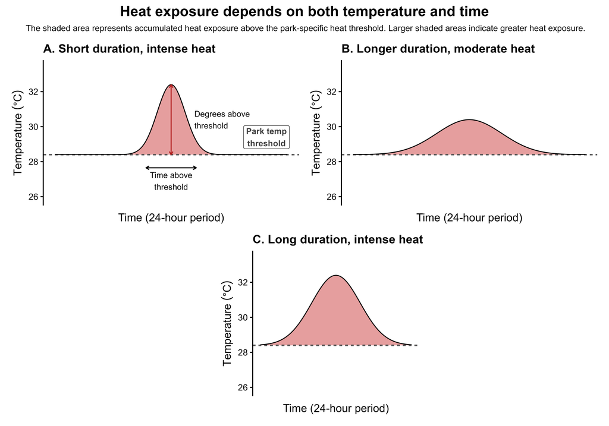

Figure 2. Conceptual illustration of Heating Degree Hours (HDH). The shaded area represents accumulated heat exposure above a park-specific heat threshold. This figure illustrates a single heat event; daily HDH is calculated by summing all periods during which temperature exceeds the threshold within a 24-hour period. Cooling Degree Hours (CDH) were calculated analogously for temperatures below the park-specific heat threshold.

### Site-Specific Extremes

Although the temperature threshold is consistent across each park, HDH and CDH values vary widely among sites. For this reason, extreme years were identified using site‑specific 90th percentiles, which allows open‑coast and partially restored systems to be evaluated on appropriate scales within a park.

### Regional Comparisons

In order to understand regional patterns of seagrass thermal stress and cooling relief among coastal parks in the Northeast, we used k-means cluster analysis to categorize each site in ASIS, CACO, and FIIS into four thermal stress regimes and four cooling relief regimes. K-means cluster analyses were conducted using 4 centers (to represent the four thermal stress or cooling relief regimes) and 2 random starts via the algorithm defined by Hartigan and Wong as implemented in the ‘kmeans’ function from the ‘stats’ package in R.

- **Episodic Heatwave**: Sites with infrequent, but intense heat events
- **Sustained Heat Stress**: Sites with frequent and prolonged heat events
- **Low Thermal Stress**: Sites with infrequent and limited time above the thermal threshold
- **Frequent Pulsed Warming**: Sites with frequent heat events that are not prolonged (pulsing)

The four cooling relief regimes were based on 1) the mean cooling degree hours averaged across all years at each site, and 2) the mean heating degree hours averaged across all years at each site. Cooling relief regimes were defined as:

- **Moderately Buffered**: Low heat stress and moderate cooling
- **Thermally Vulnerable**: High heat stress and limited cooling
- **Thermal Refugia**: Low heat stress and high cooling
- **Thermally Resilient**: High heat stress but high cooling

# Results

## Basic Site Summary

Before quantifying extreme thermal events, we summarized basic temperature conditions at each monitored site using mean, minimum, and maximum daily temperatures from May–September across years meeting data‑coverage criteria (Table 2). These values provide context for interpreting the HDH and CDH metrics presented in the following sections. The retained datasets span multiple years across CACO, FIIS, and ASIS, and show clear differences in baseline thermal conditions among parks and sites that reflect both regional climate gradients and local estuarine environments. Tingles Island, the southernmost monitoring site, exhibits the highest mean summer temperatures. In contrast, sites such as Duck Harbor and Provincetown Harbor show the lowest mean temperatures, consistent with their exposure to open coastal waters. Warmer sites such as East Harbor, Great South Bay, and Pleasant Bay reflect more enclosed estuarine conditions. Values for each site are reported in Table 2 and form the basis for subsequent analyses.

Table 2. Basic temperature summary (May–September), averaged across all retained years for all monitored sites across CACO, FIIS, and ASIS.

| Park | Site | Mean Temp (°C) | Mean Min Temp (°C) | Mean Max Temp (°C) | N years | First year | Last year |
| --- | --- | --- | --- | --- | --- | --- | --- |
| ASIS | Tingles Island | 24.9 | 12.9 | 33.1 | 15 | 2010 | 2024 |
| CACO | Duck Harbor | 18.8 | 7.4 | 26.7 | 20 | 2004 | 2023 |
| CACO | East Harbor | 22.5 | 11.4 | 30.2 | 2 | 2022 | 2023 |
| CACO | Pleasant Bay | 20.5 | 9.8 | 29.0 | 21 | 2004 | 2024 |
| CACO | Provincetown Harbor | 18.9 | 8.0 | 27.4 | 2 | 2023 | 2024 |
| FIIS | Great South Bay | 22.9 | 10.5 | 31.0 | 6 | 2019 | 2024 |
| FIIS | Moriches Bay (Great Gun) | 21.4 | 10.0 | 30.0 | 3 | 2022 | 2024 |

Note:  
East Harbor and Provincetown Harbor have fewer retained years because they began temperature monitoring only recently.

## Extreme High Heat Years

At CACO Duck Harbor, the mean annual HDH ranged from 0 in 2004 to 4.3 in 2022 across the 20 years of record. At CACO Pleasant Bay, the mean annual HDH ranged from 0.4 in 2009 to 10.6 in 2022 across the 21 years of record. Higher HDH values indicate more cumulative heat exposure resulting from higher temperatures, longer periods above the threshold, or both. Extreme high heat years occurred in 2020 and 2022 for Duck Harbor, 2023 for East Harbor, 2016, 2018, and 2022 for Pleasant Bay, and 2023 for Provincetown Harbor representing the years when the mean HDH exceeded the site-specific 90th percentile threshold (Figure 3).

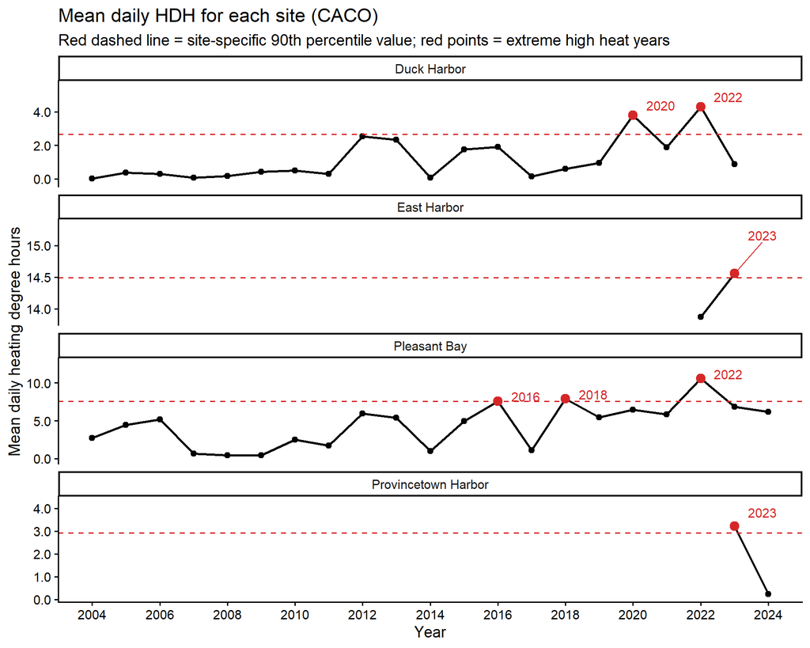

## Extreme Low Cooling Years

At CACO Duck Harbor, the mean CDH ranged from -159.6 in 2009 to -112.8 in 2022 across the 20 years of record. At CACO Pleasant Bay, the mean CDH ranged from -145 in 2009 to -80 in 2021 across the 21 years of record. CDH values closer to zero indicate less cooling (i.e., warmer conditions), whereas more negative values indicate greater cumulative cooling below the threshold. Years with exceptionally weak cooling occurred in 2021 and 2022 for Duck Harbor, 2022 for East Harbor, 2021, 2022, and 2023 for Pleasant Bay, and 2023 for Provincetown Harbor representing the years when the mean CDH exceeded the site-specific 90th percentile threshold (Figure 4).

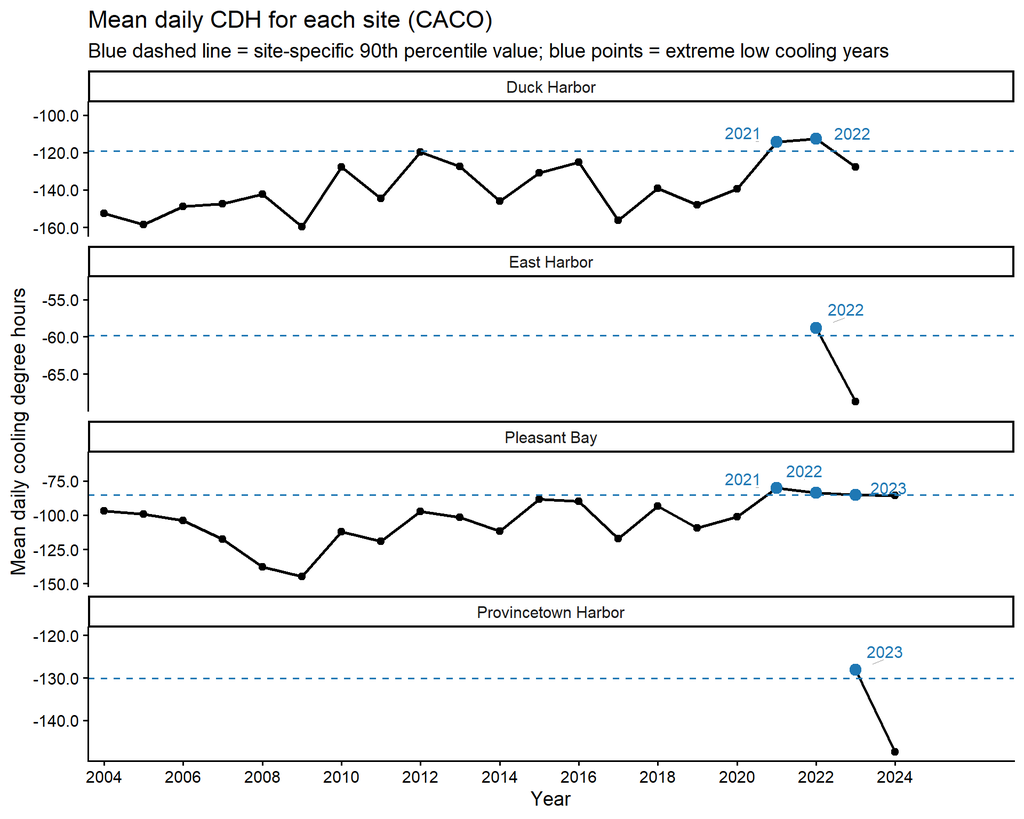

## Compound Stress Years

Compound stress years are those in which both extreme high heat and extreme low cooling occur simultaneously, indicating years when eelgrass experienced the greatest combined thermal stress. Compound stress years occurred in 2022 for Duck Harbor, 2022 for Pleasant Bay, and 2023 for Provincetown Harbor (Figure 5). There were no compound stress years at East Harbor.

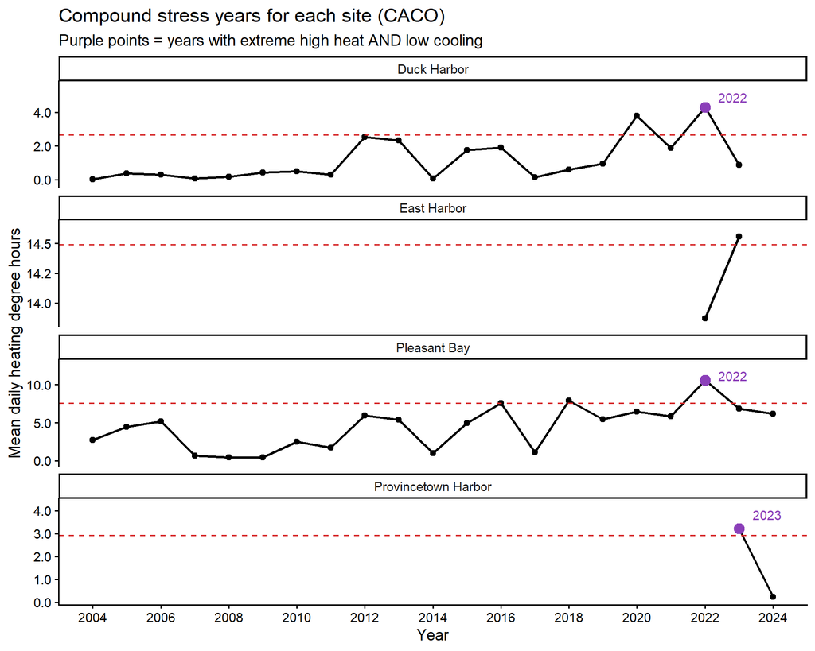

## Thermal Stress Regimes Across NCBN Parks

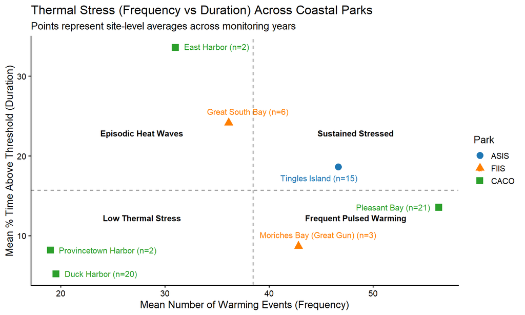

Figure 6. Thermal stress regimes across three coastal National Park Service units (CACO, ASIS, FIIS). Each point represents a site-level average of the mean number of warming events per year (frequency) and the mean percentage of time above the thermal threshold (duration). Dashed lines divide the figure into four interpretive thermal regimes. Labels show the average number of monitoring years contributing to each site-level estimate.

Although this report focuses on CACO, interpreting these temperature patterns requires understanding how CACO compares to other NCBN parks. The following section describes the CACO results in regional context using the same thermal metrics applied at the other coastal parks.

In contrast, Tingles Island at ASIS experienced heat stress much more often, and these events accumulated throughout the season. This pattern was expected for parks located in warmer parts of the region, where longer and more frequent heat events were common. FIIS sites fell between these two extremes and heat‑stress conditions varied widely between the two monitoring sites, depending on local hydrology and where each site was located. Moriches Bay showed short, frequent warming events, while Great South Bay experienced fewer warming events that lasted longer. This mix reflected the diversity of habitats and local conditions across Fire Island. These results show that sites across the regional scale experience different heat stress conditions and even sites within the same park differ greatly in their thermal regimes.

## Cooling Relief Regimes Across NCBN Parks

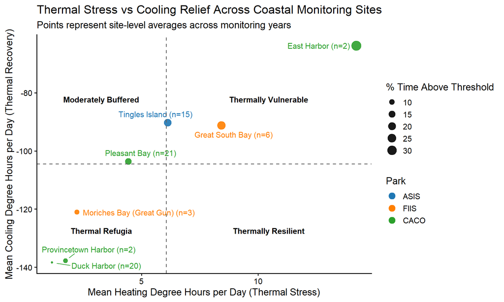

Figure 7. Thermal stress and cooling relief across three coastal National Park Service units (CACO, ASIS, FIIS). Each point represents a site‑level average of the mean heating degree hours per day (thermal stress) and the mean cooling degree hours per day (thermal relief). Dashed lines divide the figure into four cooling relief regimes. Labels show the average number of monitoring years contributing to each site‑level estimate.

Having characterized the variation in thermal stress across sites, we next evaluated the degree to which cooling events provided relief from these conditions. To support this assessment, eelgrass beds were classified into four previously defined cooling‑regime categories that reflected the balance between accumulated thermal stress and cooling. This framework enabled a comparative evaluation of site responses to heat exposure and informed the interpretation of broader temperature‑driven vulnerability patterns.

The balance between heat stress events and cooling relief varied greatly across the region and within parks. Pleasant Bay and Moriches Bay received some of the strongest cooling periods among the pulsed warming sites, second only to the fully open tidal systems on Cape Cod. This pattern reflects their position relative to inlets where tidal flushing brings in cooler ocean water that helps moderate warmer temperatures. In contrast, sites with more limited flushing, like Great South Bay and East Harbor, showed weaker cooling relief. These sites are characterized by severely reduced eelgrass, persisting only as sparse, ephemeral patches or absent all together. Tingles Island falls between these two outcomes as it receives little cooling, sits between a moderately buffered and thermally vulnerable zone, and supports patches of eelgrass.

# Key Takeaways

### CACO Key Takeaways

Across Cape Cod, eelgrass sites span a wide range of thermal regimes driven by local hydrodynamics. These range from open coast settings with relatively low heat stress (Duck Harbor and Provincetown Harbor), to coastal lagoons like Pleasant Bay, and highly restricted systems such as East Harbor. **East Harbor was the most heat stressed NCBN site** in terms of eelgrass thermal tolerance, experiencing infrequent but intense heat events that far exceeded typical seasonal conditions. Currently, East Harbor contains small (1-2 m) ephemeral patches of eelgrass confined to a very small lagoon, whereas Pleasant Bay and Provincetown Harbor maintain eelgrass beds that benefit from stronger tidal cooling, which shortens the duration of heat waves.

While this analysis focuses on thermal conditions alone, other water quality factors such as light availability, dissolved oxygen, salinity, and physical disturbance also play a key role in shaping eelgrass condition. Long-term trend analyses (Nagel et al. 2025c) show a marked decline in eelgrass condition across multiple metrics at Duck Harbor, while in Pleasant Bay eelgrass continues to persist at the mid-depth transect despite an overall decline in eelgrass condition on other transects. These patterns were likely driven by a combination of wave energy (erosion or burial), reduced water clarity, and prolonged summer heat stress. The next step in this work is to investigate the various drivers of eelgrass condition change by integrating the thermal metrics derived here with additional water quality and environmental data.

In parallel with this work, NPS scientists and partners are using genomics to better understand why some eelgrass populations are able to withstand warming while others decline. By sequencing plants from Maine to North Carolina, genetic differences linked to heat tolerance and local adaptation can be identified. These findings will guide future restoration planning and help identify donor populations for seed transplanting to support vulnerable meadows as temperatures continue to rise.

> **🟦 Network‑Wide Key Takeaways**

> • Across NCBN coastal parks, eelgrass beds experience a wide range of thermal conditions, from sites with prolonged, cumulative heat exposure to sites with strong cooling capacity.

> • Understanding both heating intensity and cooling relief provides essential context for interpreting long‑term eelgrass trends, genomic thermal tolerance, and vulnerability to climate‑driven change.

> • Applying thermal metrics alongside genomic data will help identify populations with potential heat tolerance and strengthen site‑selection models for restoration and rehabilitation.

> • Integrating assessments of long-term trends in eelgrass distribution and condition with temperature patterns will help parks diagnose change, identify drivers of decline, and prioritize management actions.

*These thermal metrics are part of an ongoing collaborative project and represent a novel approach to characterizing eelgrass stress across NCBN parks. Thresholds linking these metrics to genomic patterns and adaptive capacity are still being refined in coordination with project cooperators. Readers can learn more about the broader genomics effort, restoration framework, and supporting documentation on the [Resilient Eelgrass Project Sharepoint](https://doimspp.sharepoint.com/:u:/r/sites/nps-ncbn/SitePages/Seagrass-Resilience-%26-Restoration.aspx?csf=1&web=1&e=nbw5PA).*

# References

Berger, A.C. & Berg, P. (2024) Eelgrass meadow response to heat stress. I. Temperature threshold for ecosystem production derived from in situ aquatic eddy covariance measurements. Marine Ecology Progress Series 736:35-46. https://doi.org/10.3354/meps14587

Berger A.C., Berg P., McGlathery K.J., Aoki L.R., & Kerns K. (2024) Eelgrass meadow response to heat stress. II. Impacts of ocean warming and marine heatwaves measured by novel metrics. Marine Ecology Progress Series 736:47-62. https://doi.org/10.3354/meps14588

Carr, J.A., D’Odorico, P., McGlathery, K.J., & Wiberg, P.L. (2012) Modeling the effects of climate change on eelgrass stability and resilience: Future scenarios and leading indicators of collapse. Marine Ecology Progress Series 448:289-301. https://doi.org/10.3354/meps09556

Dunic, J.C., & Côté, I.M. (2023) Management thresholds shift under the influence of multiple stressors: eelgrass meadows as a case study. Conservation Letters 16:e12938. https://doi.org/10.1111/conl.12938

Easterling, D.R., Meehl, G.A., Parmesan, C., Changnon, S.A., Karl, T.R., & Mearns, L.O. (2000) Climate extremes: Observations, modeling, and impacts. Science 289:2068-2075. https://doi.org/10.1126/science.289.5487.2068

Fourqurean, J.W., Duarte, C.M., Kennedy, H., Marbà, N., Holmer, M., Mateo, M.A., Apostolaki, E.T., Kendrick, G.A., Krause-Jensen, D., McGlathery, K.J., & Serrano, O. (2012) Seagrass ecosystems as a globally significant carbon stock. Nature Geoscience 5:505-509. https://doi.org/10.1038/ngeo1477

Germain, S.J., & Lutz, J.A. (2020) Climate extremes may be more important than climate means when predicting species range shifts. Climate Change 163:579-598. https://doi.org/10.1007/s10584-020-02868-2

Hartigan, J.A., & Wong, M.A. (1979) Algorithm AS 136: A k-means clustering algorithm. Applied Statistics 28:100-108. https://doi.org/10.2307/2346830

Hobday, A.J., Alexander, L.V., Perkins, S.E., Smale, D.A., Straub, S.C., Oliver, E.C.J., Benthuysen, J.A., Burrows, M.T., Donat, M.G., Feng, M., Holbrook, N.J., Moore, P.J., Scannell, H.A., Gupta, A.S., & Wernberg, T. (2016) A hierarchical approach to defining marine heatwaves. Progress in Oceanography 141: 227– 238. https://doi.org/10.1016/j.pocean.2015.12.014

Hemminga, M.A., & Duarte, C.M. (2000) Seagrass ecology. Cambridge University Press. https://doi.org/10.4319/lo.2002.47.2.0611

IPCC (2023) Climate Change 2023: Synthesis Report. Contribution of Working Groups I, II and III to the Sixth Assessment Report of the Intergovernmental Panel on Climate Change [Core Writing Team, H. Lee and J. Romero (eds.)]. IPCC, Geneva, Switzerland, 184 pp. https://doi.org/10.59327/IPCC/AR6-9789291691647.

Jarvis, J.C., & Moore, K.A. (2010) The role of the photosynthetic pathway in the acclimation of Zostera marina to light and temperature stress. Journal of Experimental Marine Biology and Ecology 395:105–110.

Jentsch, A., & Beierkuhnlein, C. (2008) Research frontiers in climate change: Effects of extreme meteorological events on ecosystems. Comptes Rendus Geoscience 340:621-628. https://doi.org/10.1016/j.crte.2008.07.002

Kopp, B.S., & Neckles, H.A. (2009) A protocol for monitoring estuarine nutrient enrichment in coastal parks of the National Park Service Northeast Region. Natural Resource Report NPS/NCBN/NRR—2009/110. National Park Service, Fort Collins, Colorado. https://irma.nps.gov/DataStore/Reference/Profile/661689

Lee, K. Park, S.R., & Kim, Y.K. (2007) Effects of irradiance, temperature, and nutrients on growth dynamics of seagrasses: A review. Journal of Experimental Marine Biology and Ecology 350:144-175. https://doi.org/10.1016/j.jembe.2007.06.016

Lefcheck, J.S., Wilcox, D.J., Murphy, R.R., Marion, S.R., & Orth, R.J. (2017) Multiple stressors threaten the imperiled coastal foundation species eelgrass (*Zostera marina*) in Chesapeake Bay, USA. Global Change Biology 23:3474-3483. https://doi.org/10.1111/gcb.13623

Marín-Guirao, L., Ruiz, J.M., Dattolo, E., Garcia-Munoz, R., & Procaccini, G. (2016) Physiological and molecular evidence of differential short-term heat tolerance in Mediterranean seagrasses. Scientific Reports 6:28615. https://doi.org/10.1038/srep28615

Marsh Jr, J.A., Dennison, W.C., & Alberte, R.S. (1986) Effects of temperature on photosynthesis and respiration in eelgrass (*Zostera marina L.*). Journal of Experimental Marine Biology and Ecology 101:257-267. https://doi.org/10.1016/0022-0981(86)90267-4

Meehl, G.A., & Tebaldi C. (2004) More intense, more frequent, and longer lasting heat waves in the 21<sup>st</sup> century. Science 305:994-997. https://doi.org/10.1126/science.1098704

Moore, K.A., & Jarvis, J.C. (2008) Environmental factors affecting recent summertime eelgrass diebacks in the Lower Chesapeake Bay: Implications for long-term persistence. Journal of Coastal Research 2008:135-147. https://doi.org/10.2112/SI55-014

Nagel, J.L., Plaisted, H.K., Peck, C.P., & Duffy, P. (2025a) Condition and trends of estuarine water quality and seagrass in Assateague Island National Seashore: Northeast Coastal and Barrier Network, 2005–2022. Science Report NPS/SR—2025/273. National Park Service, Fort Collins, Colorado. https://doi.org/10.36967/2310561

Nagel, J.L., Plaisted, H.K., Peck, C.P., & Duffy, P. (2025b) Condition and trends of estuarine water quality and seagrass in Cape Cod National Seashore: Northeast Coastal and Barrier Network, 2003–2022. Science Report NPS/SR—2025/267. National Park Service, Fort Collins, Colorado. https://doi.org/10.36967/2310108

Nagel, J.L., Plaisted, H.K., Peck, C.P., & Duffy, P. (2025c) Condition and trends of estuarine water quality and seagrass in Fire Island National Seashore: Northeast Coastal and Barrier Network, 2003–2022. Science Report NPS/SR—2025/294. National Park Service, Fort Collins, Colorado. https://doi.org/10.36967/2311455

Novak, A.B., Pelletier, M.C., Colarusso, P., Simpson, J., Gutierrez, M.N., Arias-Ortiz, A., & Vella, P. (2020) Factors influencing carbon stocks and accumulation rates in eelgrass meadows across New England, USA. Estuaries and Coasts, 43:2076-2091. https://doi.org/10.1007/s12237-020-00754-9

Novak, A.B., Plaisted, H.K., Hughes, Z.J., Mittermayr, A., & Molden, E. (2023) Eelgrass (*Zostera marina L.*) populations are threatened by high sea-surface temperatures and impaired waters on Nantucket Island, USA. Marine Pollution Bulletin 197:115689. https://doi.org/10.1016/j.marpolbul.2023.115689

Moore, K.A., Shields, E.C., Parrish, D.B., & Orth, R.J. (2012) Eelgrass survival in two contrasting systems: role of turbidity and summer water temperatures. Marine Ecology Progress Series, 448:247-258. https://doi.org/10.3354/meps09578

Orth, R.J., Carruthers, T.J., Dennison, W.C., Duarte, C.M., Fourqurean, J.W., Heck, K.L., Hughes, A.R., Kendrick, G.A., Kenworthy, W.J., Olyarnik, S., Short, F.T., Waycott, M. & Williams, S. L. (2006) A global crisis for seagrass ecosystems. BioScience 56:987-996. https://doi.org/10.1641/0006-3568(2006)56[987:AGCFSE]2.0.CO;2

Orth, R.J., Lefcheck, J.S., McGlathery, K.S., Aoki, L., Luckenbach, M.W., Moore, K.A., & Lusk, B. (2020) Restoration of seagrass habitat leads to rapid recovery of coastal ecosystem services. Science Advances 6:eabc6434. https://doi.org/10.1126/sciadv.abc6434

Osland, M.J., Day, R.H., Hall, C.T., Brumfield, M.D., Dugas, J.L., & Jones, W.R. (2017) Mangrove expansion and contraction at a poleward range limit: Climate extremes and land-ocean temperature gradients. Ecology 98:125-137. https://doi.org/10.1002/ecy.1625

Parmesan, C., Root, T.L., & Willig, M.R. (2000) Impacts of extreme weather and climate on terrestrial biota. Bulletin of the American Meteorological Society 81:443-450. https://doi.org/10.1175/1520-0477(2000)081<0443:IOEWAC2.3.CO;2

Plaisted, H.K., Shields, E.C., Novak, A.B., Peck, C.P., Schenck, F., Carr, J., Duffy, P.A., Evans, N.T., Fox, S.E., Heck, S.M., Hudson, R., Mattera, T., Moore, K.A., Neikirk, B., Parrish, D.B., Peterson, B.J., Short, F.T. & Tinoco, A.I. (2022) Influence of rising water temperature on the temperate seagrass species eelgrass (*Zostera marina L.*) in the Northeast USA. Frontiers in Marine Science 9:920699. https://doi.org/10.3389/fmars.2022.920699

Shields, E.C., Parrish, D., & Moore, K. (2019). Short-term temperature stress results in seagrass community shift in a temperate estuary. Estuaries and Coasts 42:755-764. https://doi.org/10.1007/s12237-019-00517-1

Skirving, W., Marsh, B., De La Cour, J., Liu, G., Harris, A., Maturi, E., Geiger, E. & Eakin, C.M. (2020) CoralTemp and the coral reef watch coral bleaching heat stress product suite version 3.1. Remote Sensing 12:3856. https://doi.org/10.3390/rs12233856

Smale, D.A., Wernberg, T., Oliver, E.C., Thomsen, M., Harvey, B.P., Straub, S.C., Burrows, M.T., Alexander, L.V., Benthuysen, J.A., Donat, M.G., Feng, M., Hobday, A.J., Holbrook, N.J., Perkins-Kirkpatrick, S.E., Scannell H.A., Sen Gupta, A., Payne, B.L., & Moore, P.J. (2019) Marine heatwaves threaten global biodiversity and the provision of ecosystem services. Nature Climate Change 9:306-312. https://doi.org/10.1038/s41558-019-0412-1

Sogin, E.M., Michellod, D., Gruber-Vodicka, H.R., Bourceau, P., Geier, B., Meier, D.V., Seidel, M., Ahmerkamp, S., Schorn, S., D’Angelo, G., Procaccini, G., Dubilier, N., & Liebeke, M. (2022) Sugars dominate the seagrass rhizosphere. Nature Ecology & Evolution 6:866-877. https://doi.org/10.1038/s41559-022-01740-z

Zimmermann, N.E., Yoccoz, N.G., Edwards Jr., T.C., Meier, E.S., Thuiller, W., Guisan, A., Schmatz, D.R., & Pearman, P.B. (2009) Climatic extremes improve predictions of spatial patterns of tree species. Proceedings of the National Academy of Sciences 106:19723-19728. https://doi.org/10.1073/pnas.0901643106

## Contact Information

Katie Button, NCBN Biologist  
Kaitlyn_Button@nps.gov  
Holly Plaisted, NCBN Biologist & Seagrass Protocol Lead  
Holly_Plaisted@nps.gov  
Laura Feher, NCBN Biologist & Data Manager  
laura_feher@nps.gov  
[Vital Signs: Northeastern Coastal & Barrier Inventory and Monitoring Network](https://www.nps.gov/im/ncbn/what-we-monitor.htm)  
[Reports & Publications (U.S. National Park Service) (nps.gov)](https://www.nps.gov/im/ncbn/reports-publications-data.htm)